# LAB 1: ANN and PyTorch

In this lab, you will start off by constructing a neural networks from scratch to get a stronger understanding of what is required to make neural networks work.

Then in the second part of the lab you will train a neural network (using PyTorch) to classify an image into one of two classes: "car" or "truck". The code for the neural networks you train will be written for you, and you are not (yet!) expected to understand all provided code. However, by the end of the lab, you should be able to:

1. Understand at a high level the training loop for a machine learning model.
2. Understand the distinction between training, validation, and test data.
3. The concepts of overfitting and underfitting.
4. Investigate how different hyperparameters, such as learning rate and batch size, affect the success of training.
5. Compare an ANN (aka Multi-Layer Perceptron) with a CNN.

### What to submit

Submit an HTML file containing all your code, outputs, and write-up from parts A and B. You can produce a HTML file directly from Google Colab. The Colab instructions are provided at the end of this document.

**Do not submit any other files produced by your code.**

Include a link to your colab file in your submission.

Please use Google Colab to complete this assignment. If you want to use Jupyter Notebook, please complete the assignment and upload your Jupyter Notebook file to Google Colab for submission.

## Colab Link

Include a link to your colab file here

Colab Link: https://colab.research.google.com/drive/10s_ivyZiOWIW3mIKsEHBu5oQAoEWZZSm#scrollTo=2TrsqdNgS5ex

# PART A: Constructing a Neural Network [15 pt]

Before we get into using PyTorch to train our classifier we will go through the process of creating our neural network from scratch. We've seen in the tutorial how to build a 1-layer network, now we'll take it one step further to build a 2-layer network. This is an important exercise that everyone should attempt at least once to understand and truly appreciate the workings of neural networks.

## Part 0. Helper Functions

To help guide the construction we will use the iris dataset that was introduced in the tutorial. Provided are some helper code to get us started:

```python
# load "Iris_3class.csv" to Google Colab
from google.colab import files
uploaded = files.upload()
```

Upload widget is only available when the cell has been executed in the current browser session. Please rerun this cell to enable.

```
Saving Iris_3class.csv to Iris_3class.csv
```

```python
import pandas as pd
import numpy as np

raw_data = pd.read_csv("Iris_3class.csv", header = None)
raw_data = raw_data.values
np.random.shuffle(raw_data)
```

```python
import numpy as np
raw_data = raw_data

# split your data into training and validation
X_train = raw_data[0:100,:4]
y_train = raw_data[0:100,4:5].astype(int)
X_val = raw_data[100:,:4]
y_val = raw_data[100:,4:5].astype(int)

print(X_train.shape, y_train.shape)
print(X_train.dtype, y_train.dtype)
print(X_val.shape, y_val.shape)
print(X_val.dtype, y_val.dtype)
```

```
(100, 4) (100, 1)
float64 int64
(50, 4) (50, 1)
float64 int64
```

Recall that the neural network output consists of several nodes, one for each output class. Since the labels are provided as integers we will need to convert them into one-hot vectors to match the neural network output format.

```python
#Convert array to one-hot encoding
def to_one_hot(Y):
    n_col = np.amax(Y) + 1
    binarized = np.zeros((len(Y), n_col))
    for i in range(len(Y)):
        binarized[i, Y[i]] = 1.
    return binarized
```

```python
y_train = to_one_hot(y_train)
print(X_train.shape, y_train.shape)
print(X_train.dtype, y_train.dtype)

y_val = to_one_hot(y_val)
print(X_val.shape, y_val.shape)
print(X_val.dtype, y_val.dtype)
```

```
(100, 4) (100, 3)
float64 float64
(50, 4) (50, 3)
float64 float64
```

```python
#verify one-hot encoding
y_train[0:5,:]
```

```
array([[0., 0., 1.],
       [0., 0., 1.],
       [1., 0., 0.],
       [0., 1., 0.],
       [1., 0., 0.]])
```

### Part 1. Develop a 2-layer ANN [5 pt]

At its core a 2-layer neural network is just a few lines of code. Most of the complexity comes from setting up the training of the network.

Using vectorized form, set up the neural network training to use a cross-entropy loss function and determine the gradients with resepect to the layer 1 and layer 2 weights.

```python
# write code to create a 2-layer ANN in vectorized form

#define sigmoid
def sigmoid(x):
    return 1/(1+np.exp(-x))

#define softmax
def softmax(x):
  e = np.exp(x)
  return e/e.sum(axis=1, keepdims = True)


def ann(W, X_train, y_train):

  num_hidden = 5
  num_features = 4
  num_outputs = 3

  #Weights
  w0 = W[:20].reshape(num_features, num_hidden)
  w1 = W[20:].reshape(num_hidden, num_outputs)

  #Feed forward
  layer0 = X_train
  layer1 = sigmoid(np.dot(layer0, w0))
  layer2 = np.dot(layer1, w1)

  # softmax
  output = softmax(layer2)

  #Back propagation using gradient descent

  #cross-entropy loss
  error = -np.sum(y_train*np.log(output))

  #initialize gradients to zero
  dw0 = np.zeros((num_features,num_hidden))
  dw1 = np.zeros((num_hidden,num_outputs))

  #calculate gradients
  #Softmax and Cross Entropy Gradients for Backpropagation
  dL_du = output - y_train

  #for dw1
  du_dw1 = layer1
  #for dw0
  du_dv_hat = w1.T
  dv_hat_dv = layer1*(1-layer1)
  dv_dw0 = X_train


  #determine gradients
  dw1 += du_dw1.T.dot(dL_du)
  dw0 += dv_dw0.T.dot((dL_du).dot(du_dv_hat)*(dv_hat_dv))

  #combine gradients into one vector
  dW = np.array(list(dw0.flatten()) + list(dw1.flatten()))

  return (error, dW, output)
```

### Part 2. Train your neural network. How well does your network work on the iris dataset? [5 pt]

```python
num_hidden = 5
num_features = 4
num_outputs = 3

#initialize weights
w0 = 2*np.random.random((num_features, num_hidden)) - 1
w1 = 2*np.random.random((num_hidden, num_outputs)) - 1

#combine weights into a single vector
W = np.array(list(w0.flatten()) + list(w1.flatten()))

#train network
n = 0.001
iterations = 100000
errors = []
for i in range(iterations):
  (error, dW, y_pred) = ann(W, X_train, y_train)
  W += -dW * n
  errors.append(error)
```

```python
#examine predictions on training data
(_, _, y_pred) = ann(W, X_train, y_train)
pred = np.round(y_pred, 0)
pred[:5]
```

```
array([[0., 0., 1.],
       [0., 0., 1.],
       [1., 0., 0.],
       [0., 1., 0.],
       [1., 0., 0.]])
```

```python
#examine ground truth training data
train = np.round(y_train, 0)
train[:5]
```

```
array([[0., 0., 1.],
       [0., 0., 1.],
       [1., 0., 0.],
       [0., 1., 0.],
       [1., 0., 0.]])
```

### Part 3. Validate that the gradients were computed correctly for the 2-layer neural network you developed. [5 pt]

```python
#write code to numerical verify the gradients you calculated

num_hidden = 5
num_features = 4
num_outputs = 3

#initialize weights
w0 = 2*np.random.random((num_features, num_hidden)) - 1
w1 = 2*np.random.random((num_hidden, num_outputs)) - 1

#combine weights
W = np.array(list(w0.flatten()) + list(w1.flatten()))

#compute gradients analytically
(error, dW, y_pred) = ann(W, X_train, y_train)

#compute gradients numerically
dW_num = np.zeros((len(W),1))

for ind in range(len(W)):
  #reset gradients
  We1 = np.array(list(w0.flatten()) + list(w1.flatten()))
  We2 = np.array(list(w0.flatten()) + list(w1.flatten()))

  #increment slightly
  We1[ind] = We1[ind] + 0.0001
  We2[ind] = We2[ind] - 0.0001

  #compute errors
  (error_e1, dW_e1, y_pred1) = ann(We1, X_train, y_train)
  (error_e2, dW_e2, y_pred2) = ann(We2, X_train, y_train)

  #obtain numerical gradients
  grad_num = (error_e1-error_e2)/0.0002

  #display difference between numerical and analytic gradients
  print(round(abs(grad_num - dW[ind]), 4), grad_num, dW[ind])
```

```
0.0 11.811827438492628 11.811827698374437
0.0 -1.5700340940583146 -1.5700340429697883
0.0 -0.049483406314720924 -0.04948340486782494
0.0 -9.08835854218637 -9.088358530624891
0.0 -1.908973074904452 -1.908973011918853
0.0 9.235497448187857 9.235497480999037
0.0 -1.0880751000286182 -1.0880750824727299
0.0 -0.04030114048703126 -0.040301139736457305
0.0 -6.5916737953841675 -6.591673768377143
0.0 -1.2863096869608626 -1.2863096667165586
0.0 0.1659337004156214 0.16593384741432726
0.0 -0.42360492450654874 -0.4236049246765965
0.0 -0.00108833283718468 -0.0010883333624324197
0.0 -1.7236182687696555 -1.723618332765061
0.0 -0.5566323233097137 -0.5566323265954012
0.0 -0.9952383997102743 -0.9952383918997255
0.0 -0.06719953127287681 -0.06719953139496429
0.0 0.003080696515667114 0.003080696521858183
0.0 -0.04703394296257102 -0.04703394676690401
0.0 -0.08636854929022775 -0.08636854962445142
0.0 -16.16158888104735 -16.161588883364264
0.0 4.157816664687175 4.157816662442047
0.0 12.003772221333975 12.003772220922219
0.0 -0.6988506574145958 -0.6988506574214125
0.0 0.23646117767839314 0.23646117767049613
0.0 0.462389479807257 0.46238947975091654
0.0 -0.009722421907554235 -0.00972242184162915
0.0 0.0012170601593197716 0.0012170600943011017
0.0 0.00850536189034301 0.008505361747328044
0.0 -2.5372759437658488 -2.5372759437228143
0.0 0.7024753475803891 0.7024753475658188
0.0 1.8348005961144054 1.8348005961569946
0.0 -0.4286485739157797 -0.4286485739768339
0.0 0.10818702264714375 0.10818702265955361
0.0 0.32046155133969023 0.3204615513172803
```

# PART B: Cars vs Trucks [35 pt]

In the second part of the lab we will see how we can use PyTorch to train a neural network to identify Cars and Trucks.

```python
import numpy as np
import time
import torch
import torch.nn as nn
import torch.nn.functional as F
import torch.optim as optim
import torchvision
from torch.utils.data.sampler import SubsetRandomSampler
import torchvision.transforms as transforms
```

## Part 0. Helper Functions

We will be making use of the following helper functions. You will be asked to look at and possibly modify some of these, but you are not expected to understand all of them.

You should look at the function names and read the docstrings. If you are curious, come back and explore the code *after* making some progress on the lab.

```python
###############################################################################
# Data Loading

def get_relevant_indices(dataset, classes, target_classes):
    """ Return the indices for datapoints in the dataset that belongs to the
    desired target classes, a subset of all possible classes.

    Args:
        dataset: Dataset object
        classes: A list of strings denoting the name of each class
        target_classes: A list of strings denoting the name of desired classes
                        Should be a subset of the 'classes'
    Returns:
        indices: list of indices that have labels corresponding to one of the
                 target classes
    """
    indices = []
    for i in range(len(dataset)):
        # Check if the label is in the target classes
        label_index = dataset[i][1] # ex: 9
        label_class = classes[label_index] # ex: 'truck'
        if label_class in target_classes:
            indices.append(i)
    return indices

def get_data_loader(target_classes, batch_size):
    """ Loads images of cars and trucks, splits the data into training, validation
    and testing datasets. Returns data loaders for the three preprocessed datasets.

    Args:
        target_classes: A list of strings denoting the name of the desired
                        classes. Should be a subset of the argument 'classes'
        batch_size: A int representing the number of samples per batch

    Returns:
        train_loader: iterable training dataset organized according to batch size
        val_loader: iterable validation dataset organized according to batch size
        test_loader: iterable testing dataset organized according to batch size
        classes: A list of strings denoting the name of each class
    """

    classes = ('plane', 'car', 'bird', 'cat',
               'deer', 'dog', 'frog', 'horse', 'ship', 'truck')
    ########################################################################
    # The output of torchvision datasets are PILImage images of range [0, 1].
    # We transform them to Tensors of normalized range [-1, 1].
    transform = transforms.Compose(
        [transforms.ToTensor(),
         transforms.Normalize((0.5, 0.5, 0.5), (0.5, 0.5, 0.5))])
    # Load CIFAR10 training data
    trainset = torchvision.datasets.CIFAR10(root='./data', train=True,
                                            download=True, transform=transform)
    # Get the list of indices to sample from
    relevant_indices = get_relevant_indices(trainset, classes, target_classes)

    # Split into train and validation
    np.random.seed(1000) # Fixed numpy random seed for reproducible shuffling
    np.random.shuffle(relevant_indices)
    split = int(len(relevant_indices) * 0.8) #split at 80%

    # split into training and validation indices
    relevant_train_indices, relevant_val_indices = relevant_indices[:split], relevant_indices[split:]
    train_sampler = SubsetRandomSampler(relevant_train_indices)
    train_loader = torch.utils.data.DataLoader(trainset, batch_size=batch_size,
                                               num_workers=1, sampler=train_sampler)
    val_sampler = SubsetRandomSampler(relevant_val_indices)
    val_loader = torch.utils.data.DataLoader(trainset, batch_size=batch_size,
                                              num_workers=1, sampler=val_sampler)
    # Load CIFAR10 testing data
    testset = torchvision.datasets.CIFAR10(root='./data', train=False,
                                           download=True, transform=transform)
    # Get the list of indices to sample from
    relevant_test_indices = get_relevant_indices(testset, classes, target_classes)
    test_sampler = SubsetRandomSampler(relevant_test_indices)
    test_loader = torch.utils.data.DataLoader(testset, batch_size=batch_size,
                                             num_workers=1, sampler=test_sampler)
    return train_loader, val_loader, test_loader, classes

###############################################################################
# Training
def get_model_name(name, batch_size, learning_rate, epoch):
    """ Generate a name for the model consisting of all the hyperparameter values

    Args:
        config: Configuration object containing the hyperparameters
    Returns:
        path: A string with the hyperparameter name and value concatenated
    """
    path = "model_{0}_bs{1}_lr{2}_epoch{3}".format(name,
                                                   batch_size,
                                                   learning_rate,
                                                   epoch)
    return path

def normalize_label(labels):
    """
    Given a tensor containing 2 possible values, normalize this to 0/1

    Args:
        labels: a 1D tensor containing two possible scalar values
    Returns:
        A tensor normalize to 0/1 value
    """
    max_val = torch.max(labels)
    min_val = torch.min(labels)
    norm_labels = (labels - min_val)/(max_val - min_val)
    return norm_labels

def evaluate(net, loader, criterion):
    """ Evaluate the network on the validation set.

     Args:
         net: PyTorch neural network object
         loader: PyTorch data loader for the validation set
         criterion: The loss function
     Returns:
         err: A scalar for the avg classification error over the validation set
         loss: A scalar for the average loss function over the validation set
     """
    total_loss = 0.0
    total_err = 0.0
    total_epoch = 0
    for i, data in enumerate(loader, 0):
        inputs, labels = data
        labels = normalize_label(labels)  # Convert labels to 0/1
        outputs = net(inputs)
        loss = criterion(outputs, labels.float())
        corr = (outputs > 0.0).squeeze().long() != labels
        total_err += int(corr.sum())
        total_loss += loss.item()
        total_epoch += len(labels)
    err = float(total_err) / total_epoch
    loss = float(total_loss) / (i + 1)
    return err, loss

###############################################################################
# Training Curve
def plot_training_curve(path):
    """ Plots the training curve for a model run, given the csv files
    containing the train/validation error/loss.

    Args:
        path: The base path of the csv files produced during training
    """
    import matplotlib.pyplot as plt
    train_err = np.loadtxt("{}_train_err.csv".format(path))
    val_err = np.loadtxt("{}_val_err.csv".format(path))
    train_loss = np.loadtxt("{}_train_loss.csv".format(path))
    val_loss = np.loadtxt("{}_val_loss.csv".format(path))
    plt.title("Train vs Validation Error")
    n = len(train_err) # number of epochs
    plt.plot(range(1,n+1), train_err, label="Train")
    plt.plot(range(1,n+1), val_err, label="Validation")
    plt.xlabel("Epoch")
    plt.ylabel("Error")
    plt.legend(loc='best')
    plt.show()
    plt.title("Train vs Validation Loss")
    plt.plot(range(1,n+1), train_loss, label="Train")
    plt.plot(range(1,n+1), val_loss, label="Validation")
    plt.xlabel("Epoch")
    plt.ylabel("Loss")
    plt.legend(loc='best')
    plt.show()
```

## Part 1. Visualizing the Data [5 pt]

We will make use of some of the CIFAR-10 data set, which consists of colour images of size 32x32 pixels belonging to 10 categories. You can find out more about the dataset at https://www.cs.toronto.edu/~kriz/cifar.html

For this assignment, we will only be using the car and truck categories. We have included code that automatically downloads the dataset the first time that the main script is run.

```python
# This will download the CIFAR-10 dataset to a folder called "data"
# the first time you run this code.
train_loader, val_loader, test_loader, classes = get_data_loader(
    target_classes=["car", "truck"],
    batch_size=1) # One image per batch
```

```
Downloading https://www.cs.toronto.edu/~kriz/cifar-10-python.tar.gz to ./data/cifar-10-python.tar.gz
```

```
Extracting ./data/cifar-10-python.tar.gz to ./data
Files already downloaded and verified
```

### Part (a) -- 1 pt

Visualize some of the data by running the code below. Include the visualization in your writeup.

(You don't need to submit anything else.)

[figure not shown]

```python
import matplotlib.pyplot as plt

k = 0
for images, labels in train_loader:
    # since batch_size = 1, there is only 1 image in `images`
    image = images[0]
    # place the colour channel at the end, instead of at the beginning
    img = np.transpose(image, [1,2,0])
    # normalize pixel intensity values to [0, 1]
    img = img / 2 + 0.5
    plt.subplot(3, 5, k+1)
    plt.axis('off')
    plt.imshow(img)

    k += 1
    if k > 14:
        break
```

### Part (b) -- 2 pt

How many training examples do we have for the combined `car` and `truck` classes? What about validation examples? What about test examples?

```python
print('We have', len(train_loader), 'training examples for the combined car and truck classes.\n',
      'We have', len(val_loader), 'validation examples for the combined car and truck classes.\n',
      'We have', len(test_loader), 'test examples for the combined car and truck classes.')
```

```
We have 8000 training examples for the combined car and truck classes.
 We have 2000 validation examples for the combined car and truck classes.
 We have 2000 test examples for the combined car and truck classes.
```

### Part (c) -- 2pt

Why do we need a validation set when training our model? What happens if we judge the performance of our models using the training set loss/error instead of the validation set loss/error?

We need a validation set to make sure the model we are training has a low variance, which means the model we are tuning won't only be useful while applying on the training set. In this way, it can help us get better at tuning the model.

If we judge the performance of our models only usin the training set, then it is very possible that the model is overfitting on the training set. As a result, the model may has low error on training set, but high error on testing set.

## Part 2. Training [10 pt]

We define two neural networks, a `LargeNet` and `SmallNet`. We'll be training the networks in this section.

You won't understand fully what these networks are doing until the next few classes, and that's okay. For this assignment, please focus on learning how to train networks, and how hyperparameters affect training.

```python
class LargeNet(nn.Module):
    def __init__(self):
        super(LargeNet, self).__init__()
        self.name = "large"
        self.conv1 = nn.Conv2d(3, 5, 5)
        self.pool = nn.MaxPool2d(2, 2)
        self.conv2 = nn.Conv2d(5, 10, 5)
        self.fc1 = nn.Linear(10 * 5 * 5, 32)
        self.fc2 = nn.Linear(32, 1)

    def forward(self, x):
        x = self.pool(F.relu(self.conv1(x)))
        x = self.pool(F.relu(self.conv2(x)))
        x = x.view(-1, 10 * 5 * 5)
        x = F.relu(self.fc1(x))
        x = self.fc2(x)
        x = x.squeeze(1) # Flatten to [batch_size]
        return x
```

```python
class SmallNet(nn.Module):
    def __init__(self):
        super(SmallNet, self).__init__()
        self.name = "small"
        self.conv = nn.Conv2d(3, 5, 3)
        self.pool = nn.MaxPool2d(2, 2)
        self.fc = nn.Linear(5 * 7 * 7, 1)

    def forward(self, x):
        x = self.pool(F.relu(self.conv(x)))
        x = self.pool(x)
        x = x.view(-1, 5 * 7 * 7)
        x = self.fc(x)
        x = x.squeeze(1) # Flatten to [batch_size]
        return x
```

```python
small_net = SmallNet()
large_net = LargeNet()
```

### Part (a) -- 1pt

The methods `small_net.parameters()` and `large_net.parameters()` produces an iterator of all the trainable parameters of the network. These parameters are torch tensors containing many scalar values.

We haven't learned how how the parameters in these high-dimensional tensors will be used, but we should be able to count the number of parameters. Measuring the number of parameters in a network is one way of measuring the "size" of a network.

What is the total number of parameters in `small_net` and in `large_net`? (Hint: how many numbers are in each tensor?)

```python
for param in small_net.parameters():
    print(param.shape)
```

```
torch.Size([5, 3, 3, 3])
torch.Size([5])
torch.Size([1, 245])
torch.Size([1])
```

```python
for param in large_net.parameters():
    print(param.shape)
```

```
torch.Size([5, 3, 5, 5])
torch.Size([5])
torch.Size([10, 5, 5, 5])
torch.Size([10])
torch.Size([32, 250])
torch.Size([32])
torch.Size([1, 32])
torch.Size([1])
```

```python
sum_small_para = 0
for index, param in enumerate(small_net.parameters()):
    set_para = 1
    shape = param.shape

    for i in shape:
      set_para *= i
    print('In SmallNet, the {} tensor have parameters:'.format(index+1),set_para)
    sum_small_para += set_para
print('Total Number of parameters in SmallNet:',sum_small_para)
```

```
In SmallNet, the 1 tensor have parameters: 135
In SmallNet, the 2 tensor have parameters: 5
In SmallNet, the 3 tensor have parameters: 245
In SmallNet, the 4 tensor have parameters: 1
Total Number of parameters in SmallNet: 386
```

```python
sum_large_para = 0
for index, param in enumerate(large_net.parameters()):
    set_para = 1
    shape = param.shape

    for i in shape:
      set_para *= i
    print('In LargeNet, the {} tensor have parameters:'.format(index+1),set_para)
    sum_large_para += set_para
print('Total Number of parameters in LargeNet:',sum_large_para)
```

```
In LargeNet, the 1 tensor have parameters: 375
In LargeNet, the 2 tensor have parameters: 5
In LargeNet, the 3 tensor have parameters: 1250
In LargeNet, the 4 tensor have parameters: 10
In LargeNet, the 5 tensor have parameters: 8000
In LargeNet, the 6 tensor have parameters: 32
In LargeNet, the 7 tensor have parameters: 32
In LargeNet, the 8 tensor have parameters: 1
Total Number of parameters in LargeNet: 9705
```

```python
sum_para = sum_small_para + sum_large_para
print('Total Number of parameters:',sum_para)
```

```
Total Number of parameters: 10091
```

### The function train_net

The function `train_net` below takes an untrained neural network (like `small_net` and `large_net`) and several other parameters. You should be able to understand how this function works. The figure below shows the high level training loop for a machine learning model:

[figure not shown]

```python
def train_net(net, batch_size=64, learning_rate=0.01, num_epochs=30):
    ########################################################################
    # Train a classifier on cars vs trucks
    target_classes = ["car", "truck"]
    ########################################################################
    # Fixed PyTorch random seed for reproducible result
    torch.manual_seed(1000)
    ########################################################################
    # Obtain the PyTorch data loader objects to load batches of the datasets
    train_loader, val_loader, test_loader, classes = get_data_loader(
            target_classes, batch_size)
    ########################################################################
    # Define the Loss function and optimizer
    # The loss function will be Binary Cross Entropy (BCE). In this case we
    # will use the BCEWithLogitsLoss which takes unnormalized output from
    # the neural network and scalar label.
    # Optimizer will be SGD with Momentum.
    criterion = nn.BCEWithLogitsLoss()
    optimizer = optim.SGD(net.parameters(), lr=learning_rate, momentum=0.9)
    ########################################################################
    # Set up some numpy arrays to store the training/test loss/erruracy
    train_err = np.zeros(num_epochs)
    train_loss = np.zeros(num_epochs)
    val_err = np.zeros(num_epochs)
    val_loss = np.zeros(num_epochs)
    ########################################################################
    # Train the network
    # Loop over the data iterator and sample a new batch of training data
    # Get the output from the network, and optimize our loss function.
    start_time = time.time()
    for epoch in range(num_epochs):  # loop over the dataset multiple times
        total_train_loss = 0.0
        total_train_err = 0.0
        total_epoch = 0
        for i, data in enumerate(train_loader, 0):
            # Get the inputs
            inputs, labels = data
            labels = normalize_label(labels) # Convert labels to 0/1
            # Zero the parameter gradients
            optimizer.zero_grad()
            # Forward pass, backward pass, and optimize
            outputs = net(inputs)
            loss = criterion(outputs, labels.float())
            loss.backward()
            optimizer.step()
            # Calculate the statistics
            corr = (outputs > 0.0).squeeze().long() != labels
            total_train_err += int(corr.sum())
            total_train_loss += loss.item()
            total_epoch += len(labels)
        train_err[epoch] = float(total_train_err) / total_epoch
        train_loss[epoch] = float(total_train_loss) / (i+1)
        val_err[epoch], val_loss[epoch] = evaluate(net, val_loader, criterion)
        print(("Epoch {}: Train err: {}, Train loss: {} |"+
               "Validation err: {}, Validation loss: {}").format(
                   epoch + 1,
                   train_err[epoch],
                   train_loss[epoch],
                   val_err[epoch],
                   val_loss[epoch]))
        # Save the current model (checkpoint) to a file
        model_path = get_model_name(net.name, batch_size, learning_rate, epoch)
        torch.save(net.state_dict(), model_path)
    print('Finished Training')
    end_time = time.time()
    elapsed_time = end_time - start_time
    print("Total time elapsed: {:.2f} seconds".format(elapsed_time))
    # Write the train/test loss/err into CSV file for plotting later
    epochs = np.arange(1, num_epochs + 1)
    np.savetxt("{}_train_err.csv".format(model_path), train_err)
    np.savetxt("{}_train_loss.csv".format(model_path), train_loss)
    np.savetxt("{}_val_err.csv".format(model_path), val_err)
    np.savetxt("{}_val_loss.csv".format(model_path), val_loss)
```

### Part (b) -- 1pt

The parameters to the function `train_net` are hyperparameters of our neural network. We made these hyperparameters easy to modify so that we can tune them later on.

What are the default values of the parameters `batch_size`, `learning_rate`, and `num_epochs`?

```python
print('The default value of batch_size:', 64, '\n',
      'The default value of learning_rate:', 0.01, '\n',
      'The default value of num_epochs:',30)
```

```
The default value of batch_size: 64
 The default value of learning_rate: 0.01
 The default value of num_epochs: 30
```

### Part (c) -- 1 pt

What files are written to disk when we call `train_net` with `small_net`, and train for 5 epochs? Provide a list of all the files written to disk, and what information the files contain.

```python
train_net(small_net,num_epochs=5)
```

```
Files already downloaded and verified
Files already downloaded and verified
Epoch 1: Train err: 0.361875, Train loss: 0.6320463032722473 |Validation err: 0.348, Validation loss: 0.6224950049072504
Epoch 2: Train err: 0.305375, Train loss: 0.5873163959980011 |Validation err: 0.312, Validation loss: 0.5863733105361462
Epoch 3: Train err: 0.27975, Train loss: 0.5557361741065979 |Validation err: 0.265, Validation loss: 0.5457123527303338
Epoch 4: Train err: 0.245625, Train loss: 0.5119779367446899 |Validation err: 0.2225, Validation loss: 0.49375052005052567
Epoch 5: Train err: 0.21825, Train loss: 0.46657655811309817 |Validation err: 0.2135, Validation loss: 0.4589366056025028
Finished Training
Total time elapsed: 18.58 seconds
```

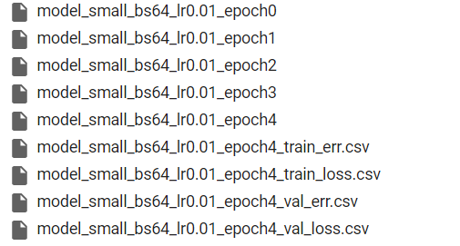

### Part (d) -- 2pt

Train both `small_net` and `large_net` using the function `train_net` and its default parameters. The function will write many files to disk, including a model checkpoint (saved values of model weights) at the end of each epoch.

If you are using Google Colab, you will need to mount Google Drive so that the files generated by `train_net` gets saved. We will be using these files in part (d). (See the Google Colab tutorial for more information about this.)

Report the total time elapsed when training each network. Which network took longer to train? Why?

```python
# Since the function writes files to disk, you will need to mount
# your Google Drive. If you are working on the lab locally, you
# can comment out this code.

from google.colab import drive
drive.mount('/content/gdrive')
```

```python
train_net(small_net)
```

```
Files already downloaded and verified
Files already downloaded and verified
Epoch 1: Train err: 0.201125, Train loss: 0.438169260263443 |Validation err: 0.2095, Validation loss: 0.44633581582456827
Epoch 2: Train err: 0.19175, Train loss: 0.41508223843574527 |Validation err: 0.1995, Validation loss: 0.43105637934058905
Epoch 3: Train err: 0.181625, Train loss: 0.4027636137008667 |Validation err: 0.189, Validation loss: 0.4145447164773941
Epoch 4: Train err: 0.18075, Train loss: 0.39366367638111116 |Validation err: 0.1885, Validation loss: 0.40940778981894255
Epoch 5: Train err: 0.16875, Train loss: 0.38184281301498413 |Validation err: 0.1785, Validation loss: 0.4089340465143323
Epoch 6: Train err: 0.16825, Train loss: 0.38168519794940947 |Validation err: 0.1805, Validation loss: 0.40606618393212557
Epoch 7: Train err: 0.1645, Train loss: 0.37330366456508635 |Validation err: 0.173, Validation loss: 0.39781404845416546
Epoch 8: Train err: 0.16025, Train loss: 0.3659303379058838 |Validation err: 0.177, Validation loss: 0.4064359995536506
Epoch 9: Train err: 0.159, Train loss: 0.367658212184906 |Validation err: 0.1945, Validation loss: 0.44183966238051653
Epoch 10: Train err: 0.1645, Train loss: 0.3721156884431839 |Validation err: 0.171, Validation loss: 0.38760985620319843
Epoch 11: Train err: 0.151125, Train loss: 0.3574233589172363 |Validation err: 0.1775, Validation loss: 0.3932135170325637
Epoch 12: Train err: 0.156125, Train loss: 0.3603323113918304 |Validation err: 0.174, Validation loss: 0.40397453028708696
Epoch 13: Train err: 0.157, Train loss: 0.36241018915176393 |Validation err: 0.169, Validation loss: 0.39181521721184254
Epoch 14: Train err: 0.156625, Train loss: 0.35964531791210175 |Validation err: 0.1735, Validation loss: 0.39069113368168473
Epoch 15: Train err: 0.168375, Train loss: 0.3777469701766968 |Validation err: 0.175, Validation loss: 0.4013296365737915
Epoch 16: Train err: 0.151125, Train loss: 0.3475193467140198 |Validation err: 0.1705, Validation loss: 0.3897234625183046
Epoch 17: Train err: 0.15325, Train loss: 0.3554432656764984 |Validation err: 0.1675, Validation loss: 0.38054285384714603
Epoch 18: Train err: 0.1555, Train loss: 0.3591597133874893 |Validation err: 0.1865, Validation loss: 0.4104194394312799
Epoch 19: Train err: 0.149625, Train loss: 0.3532905226945877 |Validation err: 0.177, Validation loss: 0.3995015164837241
Epoch 20: Train err: 0.1505, Train loss: 0.3505094287395477 |Validation err: 0.18, Validation loss: 0.4161261450499296
Epoch 21: Train err: 0.1525, Train loss: 0.3531890128850937 |Validation err: 0.182, Validation loss: 0.40888667246326804
Epoch 22: Train err: 0.15175, Train loss: 0.3512366325855255 |Validation err: 0.1745, Validation loss: 0.38858774211257696
Epoch 23: Train err: 0.155, Train loss: 0.35500471711158754 |Validation err: 0.174, Validation loss: 0.3825981761328876
Epoch 24: Train err: 0.147125, Train loss: 0.34755924570560454 |Validation err: 0.176, Validation loss: 0.38302381010726094
Epoch 25: Train err: 0.15475, Train loss: 0.3607204676866531 |Validation err: 0.1765, Validation loss: 0.38557327538728714
Epoch 26: Train err: 0.152, Train loss: 0.3557385523319244 |Validation err: 0.189, Validation loss: 0.4094544337131083
Epoch 27: Train err: 0.15075, Train loss: 0.3523911370038986 |Validation err: 0.1975, Validation loss: 0.4314563423395157
Epoch 28: Train err: 0.1475, Train loss: 0.3447152364253998 |Validation err: 0.1795, Validation loss: 0.4015313358977437
Epoch 29: Train err: 0.14925, Train loss: 0.3482843325138092 |Validation err: 0.198, Validation loss: 0.44083495531231165
Epoch 30: Train err: 0.15275, Train loss: 0.35498395609855654 |Validation err: 0.175, Validation loss: 0.3914673929102719
Finished Training
Total time elapsed: 122.13 seconds
```

```python
train_net(large_net)
```

```
Files already downloaded and verified
Files already downloaded and verified
Epoch 1: Train err: 0.411875, Train loss: 0.6706927108764649 |Validation err: 0.355, Validation loss: 0.6401819419115782
Epoch 2: Train err: 0.342375, Train loss: 0.6176457419395447 |Validation err: 0.3345, Validation loss: 0.6060220608487725
Epoch 3: Train err: 0.28725, Train loss: 0.5569689347743988 |Validation err: 0.245, Validation loss: 0.5062915440648794
Epoch 4: Train err: 0.222, Train loss: 0.48138598227500917 |Validation err: 0.1985, Validation loss: 0.4373289756476879
Epoch 5: Train err: 0.181125, Train loss: 0.4208789614439011 |Validation err: 0.184, Validation loss: 0.4050329220481217
Epoch 6: Train err: 0.1815, Train loss: 0.4059518209695816 |Validation err: 0.175, Validation loss: 0.3829742716625333
Epoch 7: Train err: 0.14725, Train loss: 0.3487760142087936 |Validation err: 0.1485, Validation loss: 0.3517189039848745
Epoch 8: Train err: 0.13625, Train loss: 0.3258053793907166 |Validation err: 0.1455, Validation loss: 0.34306545089930296
Epoch 9: Train err: 0.138875, Train loss: 0.32385863637924195 |Validation err: 0.169, Validation loss: 0.3884052340872586
Epoch 10: Train err: 0.125, Train loss: 0.2994056921005249 |Validation err: 0.1715, Validation loss: 0.37702105287462473
Epoch 11: Train err: 0.115625, Train loss: 0.27965872073173526 |Validation err: 0.154, Validation loss: 0.36256303219124675
Epoch 12: Train err: 0.1115, Train loss: 0.26651827442646026 |Validation err: 0.1535, Validation loss: 0.3535322714596987
Epoch 13: Train err: 0.10775, Train loss: 0.25892044204473497 |Validation err: 0.1455, Validation loss: 0.3342089457437396
Epoch 14: Train err: 0.095125, Train loss: 0.23221860200166702 |Validation err: 0.148, Validation loss: 0.3522289851680398
Epoch 15: Train err: 0.093125, Train loss: 0.22958997464179992 |Validation err: 0.148, Validation loss: 0.3569259219802916
Epoch 16: Train err: 0.0895, Train loss: 0.21499209290742874 |Validation err: 0.1285, Validation loss: 0.3386684078723192
Epoch 17: Train err: 0.077, Train loss: 0.19374110317230225 |Validation err: 0.151, Validation loss: 0.37015618197619915
Epoch 18: Train err: 0.0735, Train loss: 0.18226737651228905 |Validation err: 0.1785, Validation loss: 0.47164289513602853
Epoch 19: Train err: 0.0805, Train loss: 0.1952111517190933 |Validation err: 0.1515, Validation loss: 0.39682658901438117
Epoch 20: Train err: 0.062875, Train loss: 0.15722246173024176 |Validation err: 0.1405, Validation loss: 0.39244445133954287
Epoch 21: Train err: 0.059125, Train loss: 0.14956527432799338 |Validation err: 0.147, Validation loss: 0.38873595697805285
Epoch 22: Train err: 0.05925, Train loss: 0.15351323932409286 |Validation err: 0.1425, Validation loss: 0.4027316519059241
Epoch 23: Train err: 0.05225, Train loss: 0.13384855890274047 |Validation err: 0.163, Validation loss: 0.49239929812029004
Epoch 24: Train err: 0.051625, Train loss: 0.13429377479851246 |Validation err: 0.1295, Validation loss: 0.42092645913362503
Epoch 25: Train err: 0.039, Train loss: 0.10495185270905495 |Validation err: 0.151, Validation loss: 0.48069675103761256
Epoch 26: Train err: 0.04175, Train loss: 0.10867217354476452 |Validation err: 0.1385, Validation loss: 0.45905294083058834
Epoch 27: Train err: 0.027, Train loss: 0.07779316154122352 |Validation err: 0.148, Validation loss: 0.5157131254673004
Epoch 28: Train err: 0.0325, Train loss: 0.08365531356632709 |Validation err: 0.1485, Validation loss: 0.5598865072242916
Epoch 29: Train err: 0.02775, Train loss: 0.07869486720860004 |Validation err: 0.167, Validation loss: 0.6296389708295465
Epoch 30: Train err: 0.029, Train loss: 0.0774147403985262 |Validation err: 0.148, Validation loss: 0.5836288463324308
Finished Training
Total time elapsed: 136.80 seconds
```

### Part (e) - 2pt

Use the function `plot_training_curve` to display the trajectory of the training/validation error and the training/validation loss. You will need to use the function `get_model_name` to generate the argument to the `plot_training_curve` function.

Do this for both the small network and the large network. Include both plots in your writeup.

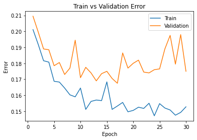

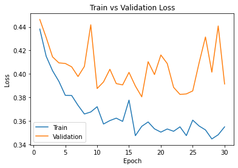

```python
#model_path = get_model_name("small", batch_size=??, learning_rate=??, epoch=29)
small_net_model_path = get_model_name("small", batch_size=64, learning_rate=0.01, epoch=29)
large_net_model_path = get_model_name("large", batch_size=64, learning_rate=0.01, epoch=29)
plot_training_curve(small_net_model_path)
```

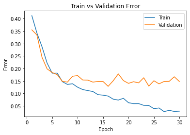

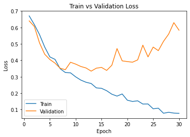

```python
plot_training_curve(large_net_model_path)
```

### Part (f) - 3pt

Describe what you notice about the training curve. How do the curves differ for `small_net` and `large_net`? Identify any occurences of underfitting and overfitting.

For both networks training curves, we can tell both of them are overfitting due to both train error curves are going down while both validation error curves are not changing at the end. And both validation error curves stop going down around the 7th epoch. The difference between two networks is that reduction of both training error and validation error curves are much more smooth in LargeNet.

## Part 3. Optimization Parameters [4 pt]

For this section, we will work with `large_net` only.

### Part (a) - 1pt

Train `large_net` with all default parameters, except set `learning_rate=0.001`. Does the model take longer/shorter to train? Plot the training curve. Describe the effect of *lowering* the learning rate.

```python
# Note: When we re-construct the model, we start the training
# with *random weights*. If we omit this code, the values of
# the weights will still be the previously trained values.
large_net = LargeNet()
train_net(large_net, learning_rate=0.001)
```

```
Files already downloaded and verified
Files already downloaded and verified
Epoch 1: Train err: 0.497625, Train loss: 0.6932131118774414 |Validation err: 0.5095, Validation loss: 0.6928170416504145
Epoch 2: Train err: 0.497375, Train loss: 0.6910982961654664 |Validation err: 0.5055, Validation loss: 0.6913520060479641
Epoch 3: Train err: 0.461875, Train loss: 0.688756489276886 |Validation err: 0.4365, Validation loss: 0.688255662098527
Epoch 4: Train err: 0.39825, Train loss: 0.684940131187439 |Validation err: 0.375, Validation loss: 0.6836362071335316
Epoch 5: Train err: 0.360625, Train loss: 0.6779827451705933 |Validation err: 0.383, Validation loss: 0.6750824060291052
Epoch 6: Train err: 0.35975, Train loss: 0.6642989201545715 |Validation err: 0.376, Validation loss: 0.6600519455969334
Epoch 7: Train err: 0.362, Train loss: 0.6440883989334106 |Validation err: 0.374, Validation loss: 0.6463453564792871
Epoch 8: Train err: 0.35825, Train loss: 0.6300292744636535 |Validation err: 0.366, Validation loss: 0.6355626247823238
Epoch 9: Train err: 0.349625, Train loss: 0.622012499332428 |Validation err: 0.353, Validation loss: 0.6274931989610195
Epoch 10: Train err: 0.34175, Train loss: 0.6143296308517456 |Validation err: 0.344, Validation loss: 0.6229213681071997
Epoch 11: Train err: 0.334, Train loss: 0.6068040871620178 |Validation err: 0.332, Validation loss: 0.6131721716374159
Epoch 12: Train err: 0.326375, Train loss: 0.5995991830825805 |Validation err: 0.331, Validation loss: 0.6021083276718855
Epoch 13: Train err: 0.318, Train loss: 0.5933025696277618 |Validation err: 0.321, Validation loss: 0.5990326348692179
Epoch 14: Train err: 0.309, Train loss: 0.5867661366462708 |Validation err: 0.3125, Validation loss: 0.5927060833200812
Epoch 15: Train err: 0.303375, Train loss: 0.581542102098465 |Validation err: 0.3135, Validation loss: 0.5820547714829445
Epoch 16: Train err: 0.2965, Train loss: 0.5742508592605591 |Validation err: 0.3075, Validation loss: 0.572761976160109
Epoch 17: Train err: 0.2935, Train loss: 0.5687983632087708 |Validation err: 0.301, Validation loss: 0.5682199150323868
Epoch 18: Train err: 0.287875, Train loss: 0.5613893430233001 |Validation err: 0.289, Validation loss: 0.5669083325192332
Epoch 19: Train err: 0.280875, Train loss: 0.5562689907550812 |Validation err: 0.2885, Validation loss: 0.5600243881344795
Epoch 20: Train err: 0.27775, Train loss: 0.5502177755832672 |Validation err: 0.28, Validation loss: 0.5558063695207238
Epoch 21: Train err: 0.271875, Train loss: 0.5448730778694153 |Validation err: 0.272, Validation loss: 0.5541261062026024
Epoch 22: Train err: 0.27, Train loss: 0.5393502216339111 |Validation err: 0.274, Validation loss: 0.5415424723178148
Epoch 23: Train err: 0.260625, Train loss: 0.5333191401958466 |Validation err: 0.286, Validation loss: 0.5472236908972263
Epoch 24: Train err: 0.25775, Train loss: 0.5289950602054596 |Validation err: 0.2645, Validation loss: 0.5357439182698727
Epoch 25: Train err: 0.25475, Train loss: 0.5228711907863617 |Validation err: 0.2685, Validation loss: 0.5352720208466053
Epoch 26: Train err: 0.24875, Train loss: 0.5181109943389892 |Validation err: 0.26, Validation loss: 0.5266622873023152
Epoch 27: Train err: 0.248, Train loss: 0.511643033504486 |Validation err: 0.258, Validation loss: 0.5204842444509268
Epoch 28: Train err: 0.2475, Train loss: 0.5074246900081635 |Validation err: 0.2535, Validation loss: 0.5154800498858094
Epoch 29: Train err: 0.2415, Train loss: 0.5017727997303009 |Validation err: 0.2495, Validation loss: 0.5109716756269336
Epoch 30: Train err: 0.238375, Train loss: 0.49520340824127196 |Validation err: 0.2465, Validation loss: 0.5074272891506553
Finished Training
Total time elapsed: 130.88 seconds
```

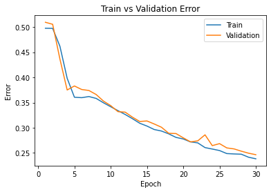

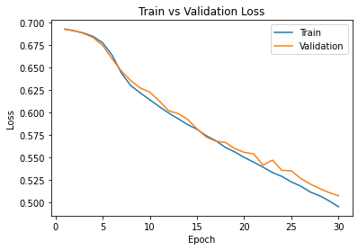

```python
large_net_model_path = get_model_name("large", batch_size=64, learning_rate=0.001, epoch=29)
plot_training_curve(large_net_model_path)
```

The model takes 130.88s to train, which is not far from 136.80s, just 6s faster.

By lowering the learning rate, the gradient descent can be carried out in a more careful way to avoid to find a suboptimal solution. As the curves show, after lowering the learning rate, the problem of overfitting disappear and both train error curve and validation error curves go down in a steady rate.

### Part (b) - 1pt

Train `large_net` with all default parameters, except set `learning_rate=0.1`. Does the model take longer/shorter to train? Plot the training curve. Describe the effect of *increasing* the learning rate.

```python
large_net = LargeNet()
train_net(large_net, learning_rate=0.1)
```

```
Files already downloaded and verified
Files already downloaded and verified
Epoch 1: Train err: 0.3435, Train loss: 0.6152465670108795 |Validation err: 0.2655, Validation loss: 0.5401884317398071
Epoch 2: Train err: 0.26275, Train loss: 0.5457514839172364 |Validation err: 0.2255, Validation loss: 0.47185863088816404
Epoch 3: Train err: 0.205125, Train loss: 0.4577759726047516 |Validation err: 0.196, Validation loss: 0.42472241446375847
Epoch 4: Train err: 0.18375, Train loss: 0.42987853920459745 |Validation err: 0.193, Validation loss: 0.4498207103461027
Epoch 5: Train err: 0.182875, Train loss: 0.4176621789932251 |Validation err: 0.1765, Validation loss: 0.3949774377979338
Epoch 6: Train err: 0.1775, Train loss: 0.407295166015625 |Validation err: 0.218, Validation loss: 0.47349493484944105
Epoch 7: Train err: 0.15425, Train loss: 0.36420914459228515 |Validation err: 0.1665, Validation loss: 0.3992267334833741
Epoch 8: Train err: 0.143125, Train loss: 0.34258134818077085 |Validation err: 0.186, Validation loss: 0.47862908942624927
Epoch 9: Train err: 0.15725, Train loss: 0.3701271313428879 |Validation err: 0.2285, Validation loss: 0.5486963000148535
Epoch 10: Train err: 0.16375, Train loss: 0.37045213639736174 |Validation err: 0.1975, Validation loss: 0.5176548413001001
Epoch 11: Train err: 0.15, Train loss: 0.3571648930311203 |Validation err: 0.1715, Validation loss: 0.44171321764588356
Epoch 12: Train err: 0.150625, Train loss: 0.3488079724311829 |Validation err: 0.1795, Validation loss: 0.39029722288250923
Epoch 13: Train err: 0.162625, Train loss: 0.3755101033449173 |Validation err: 0.158, Validation loss: 0.40274596912786365
Epoch 14: Train err: 0.161125, Train loss: 0.3735659912824631 |Validation err: 0.242, Validation loss: 0.5326617993414402
Epoch 15: Train err: 0.15375, Train loss: 0.35060252439975736 |Validation err: 0.18, Validation loss: 0.47452327888458967
Epoch 16: Train err: 0.16375, Train loss: 0.3755073459148407 |Validation err: 0.169, Validation loss: 0.47110779397189617
Epoch 17: Train err: 0.161, Train loss: 0.3715032514333725 |Validation err: 0.2335, Validation loss: 0.4700059462338686
Epoch 18: Train err: 0.169625, Train loss: 0.3888348898887634 |Validation err: 0.247, Validation loss: 0.5450323419645429
Epoch 19: Train err: 0.17175, Train loss: 0.40291259276866914 |Validation err: 0.212, Validation loss: 0.6685603959485888
Epoch 20: Train err: 0.17675, Train loss: 0.40106033146381376 |Validation err: 0.3415, Validation loss: 0.6399349188432097
Epoch 21: Train err: 0.283125, Train loss: 0.5477506041526794 |Validation err: 0.24, Validation loss: 0.5360350953415036
Epoch 22: Train err: 0.294375, Train loss: 0.5973210561275483 |Validation err: 0.4855, Validation loss: 0.6935380175709724
Epoch 23: Train err: 0.462875, Train loss: 0.7099318037033081 |Validation err: 0.5095, Validation loss: 0.6998527627438307
Epoch 24: Train err: 0.504625, Train loss: 0.6941762161254883 |Validation err: 0.5095, Validation loss: 0.6934434156864882
Epoch 25: Train err: 0.494875, Train loss: 0.6942366590499878 |Validation err: 0.5095, Validation loss: 0.6947808936238289
Epoch 26: Train err: 0.505875, Train loss: 0.6944860196113587 |Validation err: 0.5095, Validation loss: 0.6932111047208309
Epoch 27: Train err: 0.507625, Train loss: 0.6943580198287964 |Validation err: 0.5095, Validation loss: 0.6933387499302626
Epoch 28: Train err: 0.495375, Train loss: 0.6938337178230286 |Validation err: 0.5095, Validation loss: 0.6934447288513184
Epoch 29: Train err: 0.497125, Train loss: 0.6938829751014709 |Validation err: 0.5095, Validation loss: 0.6932015269994736
Epoch 30: Train err: 0.500875, Train loss: 0.6937573189735413 |Validation err: 0.4905, Validation loss: 0.6928849071264267
Finished Training
Total time elapsed: 128.69 seconds
```

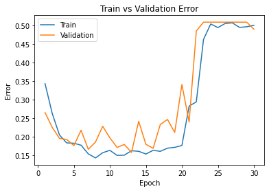

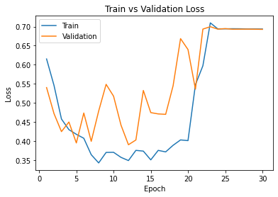

```python
large_net_model_path = get_model_name("large", batch_size=64, learning_rate=0.1, epoch=29)
plot_training_curve(large_net_model_path)
```

The model takes 128.69s to train, which is not far from 136.80s, just 8s faster.

### Part (c) - 1pt

Train `large_net` with all default parameters, including with `learning_rate=0.01`. Now, set `batch_size=512`. Does the model take longer/shorter to train? Plot the training curve. Describe the effect of *increasing* the batch size.

```python
large_net = LargeNet()
train_net(large_net, batch_size=512)
```

```
Files already downloaded and verified
Files already downloaded and verified
Epoch 1: Train err: 0.466, Train loss: 0.6923338621854782 |Validation err: 0.44, Validation loss: 0.6918952614068985
Epoch 2: Train err: 0.413, Train loss: 0.6914851702749729 |Validation err: 0.403, Validation loss: 0.6910877674818039
Epoch 3: Train err: 0.4035, Train loss: 0.6901152096688747 |Validation err: 0.3925, Validation loss: 0.6894860416650772
Epoch 4: Train err: 0.4, Train loss: 0.6876360848546028 |Validation err: 0.393, Validation loss: 0.686403214931488
Epoch 5: Train err: 0.373625, Train loss: 0.6824756488204002 |Validation err: 0.374, Validation loss: 0.6796957552433014
Epoch 6: Train err: 0.364375, Train loss: 0.6726636365056038 |Validation err: 0.3685, Validation loss: 0.6694183051586151
Epoch 7: Train err: 0.36475, Train loss: 0.6583152934908867 |Validation err: 0.3765, Validation loss: 0.659694567322731
Epoch 8: Train err: 0.365, Train loss: 0.6487302668392658 |Validation err: 0.38, Validation loss: 0.6560312807559967
Epoch 9: Train err: 0.3655, Train loss: 0.6413212195038795 |Validation err: 0.362, Validation loss: 0.6495263129472733
Epoch 10: Train err: 0.357875, Train loss: 0.632891159504652 |Validation err: 0.358, Validation loss: 0.6435617059469223
Epoch 11: Train err: 0.355375, Train loss: 0.6264823339879513 |Validation err: 0.361, Validation loss: 0.635228767991066
Epoch 12: Train err: 0.346125, Train loss: 0.6183107383549213 |Validation err: 0.358, Validation loss: 0.6272392421960831
Epoch 13: Train err: 0.34525, Train loss: 0.6089875996112823 |Validation err: 0.349, Validation loss: 0.6176133751869202
Epoch 14: Train err: 0.334625, Train loss: 0.6008952520787716 |Validation err: 0.3315, Validation loss: 0.6059800684452057
Epoch 15: Train err: 0.32325, Train loss: 0.5925093442201614 |Validation err: 0.321, Validation loss: 0.5952296555042267
Epoch 16: Train err: 0.306875, Train loss: 0.5828244425356388 |Validation err: 0.311, Validation loss: 0.5883707404136658
Epoch 17: Train err: 0.302, Train loss: 0.5724660903215408 |Validation err: 0.2985, Validation loss: 0.5751355439424515
Epoch 18: Train err: 0.292375, Train loss: 0.5632770769298077 |Validation err: 0.29, Validation loss: 0.5647772550582886
Epoch 19: Train err: 0.285625, Train loss: 0.556258074939251 |Validation err: 0.293, Validation loss: 0.556031659245491
Epoch 20: Train err: 0.275125, Train loss: 0.5431366115808487 |Validation err: 0.2935, Validation loss: 0.5488351434469223
Epoch 21: Train err: 0.25975, Train loss: 0.5302572641521692 |Validation err: 0.271, Validation loss: 0.5354964882135391
Epoch 22: Train err: 0.253125, Train loss: 0.5154020022600889 |Validation err: 0.256, Validation loss: 0.5131724923849106
Epoch 23: Train err: 0.2365, Train loss: 0.49451820366084576 |Validation err: 0.243, Validation loss: 0.5025931894779205
Epoch 24: Train err: 0.225375, Train loss: 0.479642353951931 |Validation err: 0.22, Validation loss: 0.4695930629968643
Epoch 25: Train err: 0.21625, Train loss: 0.46480998024344444 |Validation err: 0.2105, Validation loss: 0.4633626714348793
Epoch 26: Train err: 0.197625, Train loss: 0.44201053492724895 |Validation err: 0.2125, Validation loss: 0.4610237628221512
Epoch 27: Train err: 0.195875, Train loss: 0.4341062344610691 |Validation err: 0.199, Validation loss: 0.44548120349645615
Epoch 28: Train err: 0.190375, Train loss: 0.43572879396378994 |Validation err: 0.203, Validation loss: 0.44622382521629333
Epoch 29: Train err: 0.18425, Train loss: 0.41997143998742104 |Validation err: 0.1885, Validation loss: 0.4323666989803314
Epoch 30: Train err: 0.17475, Train loss: 0.40353713370859623 |Validation err: 0.1865, Validation loss: 0.42076249420642853
Finished Training
Total time elapsed: 125.12 seconds
```

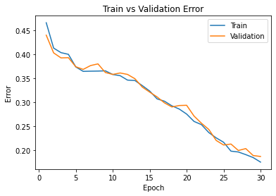

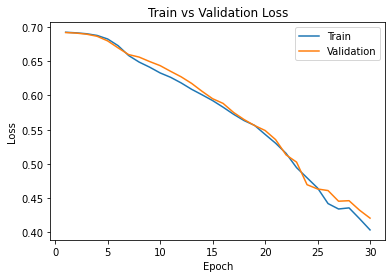

```python
large_net_model_path = get_model_name("large", batch_size=512, learning_rate=0.01, epoch=29)
plot_training_curve(large_net_model_path)
```

The model takes 125.12s to train, which is 11s faster than 136.80s.

By increse the batch size, the iteration in each epoch becomes smaller. Hence, even though the problem of overfitting disappears, more epoch is recommended for lower train error and validation error.

### Part (d) - 1pt

Train `large_net` with all default parameters, including with `learning_rate=0.01`. Now, set `batch_size=16`. Does the model take longer/shorter to train? Plot the training curve. Describe the effect of *decreasing* the batch size.

```python
large_net = LargeNet()
train_net(large_net, batch_size=16)
```

```
Files already downloaded and verified
Files already downloaded and verified
Epoch 1: Train err: 0.34375, Train loss: 0.6175165125727653 |Validation err: 0.2625, Validation loss: 0.540454069852829
Epoch 2: Train err: 0.22325, Train loss: 0.4730004854500294 |Validation err: 0.2035, Validation loss: 0.43918069565296175
Epoch 3: Train err: 0.25525, Train loss: nan |Validation err: 0.4905, Validation loss: nan
Epoch 4: Train err: 0.502375, Train loss: nan |Validation err: 0.4905, Validation loss: nan
Epoch 5: Train err: 0.502375, Train loss: nan |Validation err: 0.4905, Validation loss: nan
Epoch 6: Train err: 0.502375, Train loss: nan |Validation err: 0.4905, Validation loss: nan
Epoch 7: Train err: 0.502375, Train loss: nan |Validation err: 0.4905, Validation loss: nan
Epoch 8: Train err: 0.502375, Train loss: nan |Validation err: 0.4905, Validation loss: nan
Epoch 9: Train err: 0.502375, Train loss: nan |Validation err: 0.4905, Validation loss: nan
Epoch 10: Train err: 0.502375, Train loss: nan |Validation err: 0.4905, Validation loss: nan
Epoch 11: Train err: 0.502375, Train loss: nan |Validation err: 0.4905, Validation loss: nan
Epoch 12: Train err: 0.502375, Train loss: nan |Validation err: 0.4905, Validation loss: nan
Epoch 13: Train err: 0.502375, Train loss: nan |Validation err: 0.4905, Validation loss: nan
Epoch 14: Train err: 0.502375, Train loss: nan |Validation err: 0.4905, Validation loss: nan
Epoch 15: Train err: 0.502375, Train loss: nan |Validation err: 0.4905, Validation loss: nan
Epoch 16: Train err: 0.502375, Train loss: nan |Validation err: 0.4905, Validation loss: nan
Epoch 17: Train err: 0.502375, Train loss: nan |Validation err: 0.4905, Validation loss: nan
Epoch 18: Train err: 0.502375, Train loss: nan |Validation err: 0.4905, Validation loss: nan
Epoch 19: Train err: 0.502375, Train loss: nan |Validation err: 0.4905, Validation loss: nan
Epoch 20: Train err: 0.502375, Train loss: nan |Validation err: 0.4905, Validation loss: nan
Epoch 21: Train err: 0.502375, Train loss: nan |Validation err: 0.4905, Validation loss: nan
Epoch 22: Train err: 0.502375, Train loss: nan |Validation err: 0.4905, Validation loss: nan
Epoch 23: Train err: 0.502375, Train loss: nan |Validation err: 0.4905, Validation loss: nan
Epoch 24: Train err: 0.502375, Train loss: nan |Validation err: 0.4905, Validation loss: nan
Epoch 25: Train err: 0.502375, Train loss: nan |Validation err: 0.4905, Validation loss: nan
Epoch 26: Train err: 0.502375, Train loss: nan |Validation err: 0.4905, Validation loss: nan
Epoch 27: Train err: 0.502375, Train loss: nan |Validation err: 0.4905, Validation loss: nan
Epoch 28: Train err: 0.502375, Train loss: nan |Validation err: 0.4905, Validation loss: nan
Epoch 29: Train err: 0.502375, Train loss: nan |Validation err: 0.4905, Validation loss: nan
Epoch 30: Train err: 0.502375, Train loss: nan |Validation err: 0.4905, Validation loss: nan
Finished Training
Total time elapsed: 202.51 seconds
```

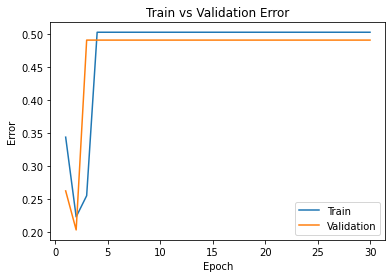

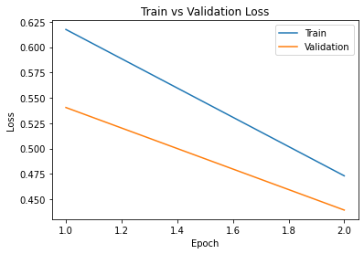

```python
large_net_model_path = get_model_name("large", batch_size=16, learning_rate=0.01, epoch=29)
plot_training_curve(large_net_model_path)
```

The model takes 202.51s to train, which is 66s slower than 136.80s.

## Part 4. Hyperparameter Search [4 pt]

### Part (a) - 1pt

Based on the plots from above, choose another set of values for the hyperparameters (network, batch_size, learning_rate) that you think would help you improve the validation accuracy. Justify your choice.

(large_net, 512, 0.001)

LargeNet is chosen for more stable performance in comparison to SmallNet. And batch_size=512 and learning_rate=0.001 is both chosen for solving the problem of overfitting, and make both train error and validation error have a stable decreasing trend.

### Part (b) - 1pt

Train the model with the hyperparameters you chose in part(a), and include the training curve.

```python
large_net = LargeNet()
train_net(large_net, batch_size=512, learning_rate = 0.001)
```

```
Files already downloaded and verified
Files already downloaded and verified
Epoch 1: Train err: 0.485875, Train loss: 0.6924983970820904 |Validation err: 0.472, Validation loss: 0.692221611738205
Epoch 2: Train err: 0.478375, Train loss: 0.6923949047923088 |Validation err: 0.4695, Validation loss: 0.692174568772316
Epoch 3: Train err: 0.46825, Train loss: 0.6923299133777618 |Validation err: 0.459, Validation loss: 0.6920875608921051
Epoch 4: Train err: 0.4585, Train loss: 0.6922332793474197 |Validation err: 0.443, Validation loss: 0.6920361071825027
Epoch 5: Train err: 0.449375, Train loss: 0.6921333856880665 |Validation err: 0.441, Validation loss: 0.6919640898704529
Epoch 6: Train err: 0.438875, Train loss: 0.6920301467180252 |Validation err: 0.433, Validation loss: 0.6918835192918777
Epoch 7: Train err: 0.429875, Train loss: 0.6919135712087154 |Validation err: 0.421, Validation loss: 0.6918077170848846
Epoch 8: Train err: 0.42025, Train loss: 0.691812664270401 |Validation err: 0.4065, Validation loss: 0.6917246580123901
Epoch 9: Train err: 0.41025, Train loss: 0.6916775777935982 |Validation err: 0.4075, Validation loss: 0.6916279345750809
Epoch 10: Train err: 0.404375, Train loss: 0.6915716230869293 |Validation err: 0.399, Validation loss: 0.6915279179811478
Epoch 11: Train err: 0.400375, Train loss: 0.6914350688457489 |Validation err: 0.401, Validation loss: 0.6914211511611938
Epoch 12: Train err: 0.399, Train loss: 0.6913158483803272 |Validation err: 0.396, Validation loss: 0.6913112998008728
Epoch 13: Train err: 0.397375, Train loss: 0.6911525763571262 |Validation err: 0.3955, Validation loss: 0.6911809593439102
Epoch 14: Train err: 0.396625, Train loss: 0.6910049207508564 |Validation err: 0.399, Validation loss: 0.6910479068756104
Epoch 15: Train err: 0.3955, Train loss: 0.6908345073461533 |Validation err: 0.402, Validation loss: 0.6909208595752716
Epoch 16: Train err: 0.39225, Train loss: 0.6906587220728397 |Validation err: 0.4005, Validation loss: 0.6907652914524078
Epoch 17: Train err: 0.391, Train loss: 0.6904520839452744 |Validation err: 0.3995, Validation loss: 0.6905977576971054
Epoch 18: Train err: 0.391, Train loss: 0.6902436725795269 |Validation err: 0.3975, Validation loss: 0.6904180198907852
Epoch 19: Train err: 0.39025, Train loss: 0.6900526396930218 |Validation err: 0.393, Validation loss: 0.6902313232421875
Epoch 20: Train err: 0.39175, Train loss: 0.6898256316781044 |Validation err: 0.39, Validation loss: 0.6900095194578171
Epoch 21: Train err: 0.389875, Train loss: 0.6895700134336948 |Validation err: 0.387, Validation loss: 0.6897897720336914
Epoch 22: Train err: 0.39075, Train loss: 0.6892999783158302 |Validation err: 0.388, Validation loss: 0.6895608752965927
Epoch 23: Train err: 0.38875, Train loss: 0.6889859810471535 |Validation err: 0.386, Validation loss: 0.689260944724083
Epoch 24: Train err: 0.38725, Train loss: 0.688675981014967 |Validation err: 0.382, Validation loss: 0.6889672726392746
Epoch 25: Train err: 0.3855, Train loss: 0.688325971364975 |Validation err: 0.3795, Validation loss: 0.6886764019727707
Epoch 26: Train err: 0.3815, Train loss: 0.6879613809287548 |Validation err: 0.3755, Validation loss: 0.6883417218923569
Epoch 27: Train err: 0.3805, Train loss: 0.6875522099435329 |Validation err: 0.3765, Validation loss: 0.6879607290029526
Epoch 28: Train err: 0.3795, Train loss: 0.6870812512934208 |Validation err: 0.3765, Validation loss: 0.6875365525484085
Epoch 29: Train err: 0.378625, Train loss: 0.6866272538900375 |Validation err: 0.378, Validation loss: 0.6871484220027924
Epoch 30: Train err: 0.37625, Train loss: 0.6860791966319084 |Validation err: 0.3765, Validation loss: 0.686616450548172
Finished Training
Total time elapsed: 107.89 seconds
```

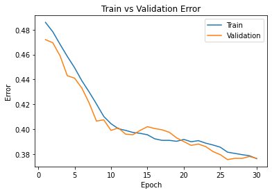

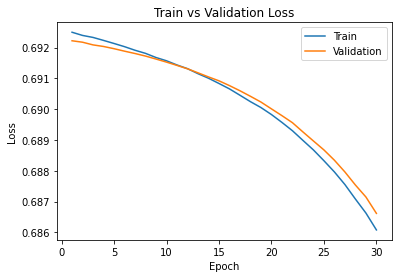

```python
large_net_model_path = get_model_name("large", batch_size=512, learning_rate=0.001, epoch=29)
plot_training_curve(large_net_model_path)
```

### Part (c) - 1pt

Based on your result from Part(a), suggest another set of hyperparameter values to try. Justify your choice.

(large_net, 256, 0.001)

In last model, both train error and validation error curves are still going down in a relatively smooth trend, but the final errors for both are still too large after 30 epochs because of the larger batch size reduces the iterations in each epoch.

LargeNet is chosen for more stable performance in comparison to SmallNet. And batch_size=256 is chosen for increase the iterations in each epoch in comparison with batch_size=512. Learning_rate=0.001 is chosen for solving the problem of overfitting, and make both train error and validation error have a stable decreasing trend.

### Part (d) - 1pt

Train the model with the hyperparameters you chose in part(c), and include the training curve.

```python
large_net = LargeNet()
train_net(large_net, batch_size=256, learning_rate = 0.001)
```

```
Files already downloaded and verified
Files already downloaded and verified
Epoch 1: Train err: 0.48225, Train loss: 0.6924561280757189 |Validation err: 0.4705, Validation loss: 0.6921727657318115
Epoch 2: Train err: 0.467125, Train loss: 0.692259119823575 |Validation err: 0.4515, Validation loss: 0.6920497119426727
Epoch 3: Train err: 0.445, Train loss: 0.6920899078249931 |Validation err: 0.4345, Validation loss: 0.6918730214238167
Epoch 4: Train err: 0.42, Train loss: 0.6918841302394867 |Validation err: 0.4095, Validation loss: 0.6917312368750572
Epoch 5: Train err: 0.404875, Train loss: 0.6916618347167969 |Validation err: 0.3965, Validation loss: 0.6915241703391075
Epoch 6: Train err: 0.40325, Train loss: 0.6913758609443903 |Validation err: 0.4, Validation loss: 0.69132861495018
Epoch 7: Train err: 0.39775, Train loss: 0.691080529242754 |Validation err: 0.4, Validation loss: 0.691053606569767
Epoch 8: Train err: 0.396375, Train loss: 0.6907492689788342 |Validation err: 0.4, Validation loss: 0.6907608211040497
Epoch 9: Train err: 0.390125, Train loss: 0.6903509236872196 |Validation err: 0.3985, Validation loss: 0.6904239654541016
Epoch 10: Train err: 0.39, Train loss: 0.6899346373975277 |Validation err: 0.392, Validation loss: 0.6900150403380394
Epoch 11: Train err: 0.390625, Train loss: 0.6894404981285334 |Validation err: 0.3865, Validation loss: 0.6895749121904373
Epoch 12: Train err: 0.388625, Train loss: 0.6888211835175753 |Validation err: 0.382, Validation loss: 0.6890059933066368
Epoch 13: Train err: 0.384, Train loss: 0.688175717368722 |Validation err: 0.3765, Validation loss: 0.6883301213383675
Epoch 14: Train err: 0.379375, Train loss: 0.6873600818216801 |Validation err: 0.377, Validation loss: 0.687548503279686
Epoch 15: Train err: 0.376625, Train loss: 0.6862844917923212 |Validation err: 0.3815, Validation loss: 0.6865670382976532
Epoch 16: Train err: 0.37325, Train loss: 0.6852485127747059 |Validation err: 0.3835, Validation loss: 0.6855187118053436
Epoch 17: Train err: 0.37325, Train loss: 0.6835411302745342 |Validation err: 0.383, Validation loss: 0.6841925606131554
Epoch 18: Train err: 0.369375, Train loss: 0.6820164453238249 |Validation err: 0.382, Validation loss: 0.6826117858290672
Epoch 19: Train err: 0.369125, Train loss: 0.6800315994769335 |Validation err: 0.375, Validation loss: 0.6806360632181168
Epoch 20: Train err: 0.368875, Train loss: 0.6776527222245932 |Validation err: 0.3725, Validation loss: 0.6783940494060516
Epoch 21: Train err: 0.365625, Train loss: 0.6755460724234581 |Validation err: 0.37, Validation loss: 0.6764975488185883
Epoch 22: Train err: 0.364625, Train loss: 0.6717240195721388 |Validation err: 0.3715, Validation loss: 0.6736452206969261
Epoch 23: Train err: 0.36425, Train loss: 0.6688943691551685 |Validation err: 0.367, Validation loss: 0.6709334030747414
Epoch 24: Train err: 0.364625, Train loss: 0.6657487601041794 |Validation err: 0.371, Validation loss: 0.668179951608181
Epoch 25: Train err: 0.3655, Train loss: 0.661961417645216 |Validation err: 0.373, Validation loss: 0.6657714918255806
Epoch 26: Train err: 0.366, Train loss: 0.6579326093196869 |Validation err: 0.3765, Validation loss: 0.6631702408194542
Epoch 27: Train err: 0.365, Train loss: 0.6559102945029736 |Validation err: 0.38, Validation loss: 0.6611797660589218
Epoch 28: Train err: 0.366375, Train loss: 0.6526940111070871 |Validation err: 0.379, Validation loss: 0.65957210958004
Epoch 29: Train err: 0.36525, Train loss: 0.650559339672327 |Validation err: 0.376, Validation loss: 0.658400185406208
Epoch 30: Train err: 0.36675, Train loss: 0.6480694767087698 |Validation err: 0.376, Validation loss: 0.6567825749516487
Finished Training
Total time elapsed: 111.93 seconds
```

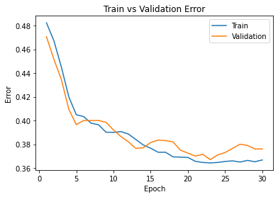

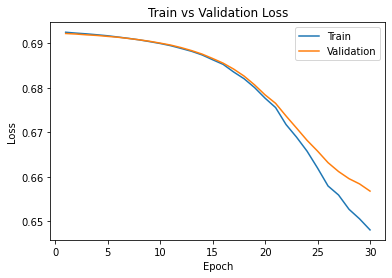

```python
large_net_model_path = get_model_name("large", batch_size=256, learning_rate=0.001, epoch=29)
plot_training_curve(large_net_model_path)
```

## Part 4. Evaluating the Best Model [9 pt]

### Part (a) - 1pt

Choose the **best** model that you have so far. This means choosing the best model checkpoint, including the choice of `small_net` vs `large_net`, the `batch_size`, `learning_rate`, **and the epoch number**.

Modify the code below to load your chosen set of weights to the model object `net`.

```python
net = LargeNet()
model_path = get_model_name(net.name, batch_size=512, learning_rate=0.01, epoch=29)
state = torch.load(model_path)
net.load_state_dict(state)
```

```
<All keys matched successfully>
```

### Part (b) - 2pt

Justify your choice of model from part (a).

### Part (c) - 2pt

Using the code in Part 0, any code from lecture notes, or any code that you write, compute and report the **test classification error** for your chosen model.

```python
# If you use the `evaluate` function provided in part 0, you will need to
# set batch_size > 1
train_loader, val_loader, test_loader, classes = get_data_loader(
    target_classes=["car", "truck"],
    batch_size=64)

criterion = nn.BCEWithLogitsLoss()
test_err, test_loss = evaluate(net, test_loader, criterion)

print('Test Classification Error:',test_err)
print('Test Classification Loss:',test_loss)
```

```
Files already downloaded and verified
Files already downloaded and verified
Test Classification Error: 0.182
Test Classification Loss: 0.41705711372196674
```

### Part (d) - 2pt

How does the test classification error compare with the **validation error**? Explain why you would expect the test error to be *higher* than the validation error.

Compare to validation error of 0.1865, the test error is very close to it as 0.182.

The reason for expecting the test error to be higher than the validation error is that validation data set was used as a guidance while training the model. So the model can definitely have better performance at validation data set than at test data set.

### Part (e) - 2pt

Why did we only use the test data set at the very end? Why is it important that we use the test data as little as possible?

We only use the test data set at the very end because the test data set is the data set that is used to test the model's ultimate performance. Hence, it's important for the test data is used as little as possible during the training to avoid the model adapted the test data set, so the test data set can be used to simulate any random data from the whole data set.

## Part 5. Fully-Connected Linear ANN vs CNN [3 pt]

Test out a 3-layer linear fully-connected ANN architecture (see simpleANN below). You should explore different hyperparameter settings to determine how well you can do on the validation dataset. Once satisified with the performance, you may test it out on the test data.

```python
class simpleANN(nn.Module):
    def __init__(self):
        super(simpleANN, self).__init__()
        self.name = "simple"
        self.fc1 = nn.Linear(32*32*3, 100)
        self.fc2 = nn.Linear(100, 20)
        self.fc3 = nn.Linear(20, 1)

    def forward(self, x):
        x = x.view(-1, 32*32*3)
        x = F.relu(self.fc1(x))
        x = F.relu(self.fc2(x))
        x = self.fc3(x)
        x = x.squeeze(1) # Flatten to [batch_size]
        return x
```

### Saving to HTML

Detailed instructions for saving to HTML can be found [here](https://stackoverflow.com/questions/53460051/convert-ipynb-notebook-to-html-in-google-colab/64487858#64487858). Provided below are a summary of the instructions:

(1) download your ipynb file by clicking on File->Download.ipynb

(2) reupload your file to the temporary Google Colab storage (you can access the temporary storage from the tab to the left)

(3) run the following:

```python
%%shell
jupyter nbconvert --to html LAB_1_ANN_and_PyTorch.ipynb
```

```
[NbConvertApp] Converting notebook LAB_1_ANN_and_PyTorch.ipynb to html
[NbConvertApp] Writing 1012936 bytes to LAB_1_ANN_and_PyTorch.html
```

(4) the html file will be available for download in the temporary Google Colab storage

(5) review the html file and make sure all the results are visible before submitting your assignment to Quercus